## Homework #2

## July 17, 2023

# Question #1

**Paper Critique**

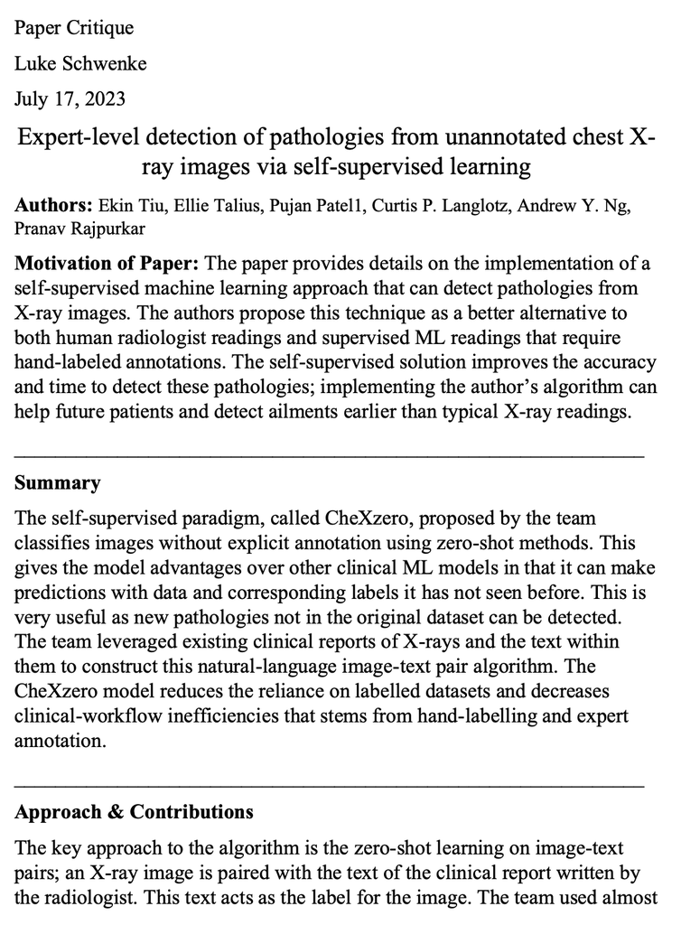

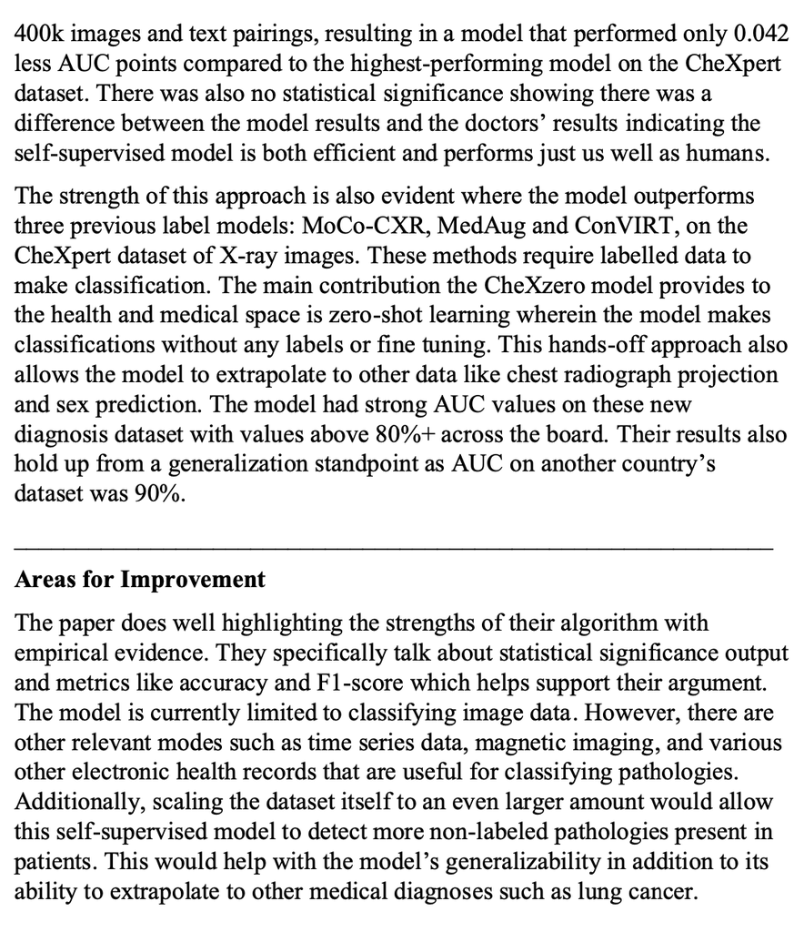

# Question #2

**Build a small neural network without using the Keras API:**

- Train the model on an artificially generated dataset of your choice.
- You may use TF API functions such as GradientTape or SGD optimizer for backpropagation.

Ensure GPU is connected

```python
import sys
import tensorflow.keras
import pandas as pd
import sklearn as sk
import scipy as sp
import tensorflow as tf
import platform
print(f"Python Platform: {platform.platform()}")
print(f"Tensor Flow Version: {tf.__version__}")
print(f"Keras Version: {tensorflow.keras.__version__}")
print()
print(f"Python {sys.version}")
print(f"Pandas {pd.__version__}")
print(f"Scikit-Learn {sk.__version__}")
print(f"SciPy {sp.__version__}")
gpu = len(tf.config.list_physical_devices('GPU'))>0
print("GPU is", "available" if gpu else "NOT AVAILABLE")
```

```
Python Platform: macOS-13.4.1-arm64-arm-64bit
Tensor Flow Version: 2.12.0
Keras Version: 2.12.0

Python 3.10.10 (main, Mar 21 2023, 13:41:05) [Clang 14.0.6 ]
Pandas 2.0.2
Scikit-Learn 1.2.2
SciPy 1.10.1
GPU is available
```

```python
tf.config.list_physical_devices()
```

```
[PhysicalDevice(name='/physical_device:CPU:0', device_type='CPU'),
 PhysicalDevice(name='/physical_device:GPU:0', device_type='GPU')]
```

```python
import numpy as np
from sklearn.model_selection import train_test_split
import pandas as pd
import matplotlib.pyplot as plt
import math
import pandas as pd
from sklearn.preprocessing import StandardScaler
from tensorflow import keras
from tensorflow.keras.datasets import mnist
from tensorflow.keras.models import Sequential
from tensorflow.keras.layers import Dense, BatchNormalization, Dropout
from tensorflow.keras.callbacks import EarlyStopping, ModelCheckpoint, TensorBoard
from tensorflow.keras import regularizers
from tensorflow.keras.utils import plot_model
from sklearn.metrics import accuracy_score, precision_score, recall_score, f1_score
from sklearn.linear_model import LogisticRegression
from sklearn.svm import SVC
import random
```

```python
# Initialize various inputs
inputs = []

for _ in range(20):
    number = round(random.uniform(1, 6), 1)
    inputs.append(number)

print("inputs =",inputs)
```

```
inputs = [3.5, 1.1, 5.6, 4.0, 3.6, 5.4, 1.5, 2.1, 4.8, 4.4, 5.3, 1.6, 3.6, 5.6, 3.0, 1.1, 5.9, 3.7, 2.6, 2.7]
```

```python
# Initialize bias terms
biases = []

for _ in range(3):
    number = round(random.uniform(1, 3), 1)
    biases.append(number)

print("biases =", biases)
```

```
biases = [1.8, 1.4, 2.1]
```

```python
# Initialize random weights
weights = []

for _ in range(3):
    sublist = []
    for _ in range(20):
        weight = round(random.uniform(-1, 1), 1)
        sublist.append(weight)
    weights.append(sublist)

print("weights =", weights)
```

[output not shown]

```python
# Construct formula for the outputs
outputs = np.dot(weights, inputs) + biases

print (outputs)
```

```
[ 5.11  9.19 -7.09]
```

```python
import random

a = []

for _ in range(20):
    number = random.randint(0, 1)
    a.append(number)


b = []

for _ in range(20):
    number = random.randint(0, 1)
    b.append(number)
```

```python
a
```

```
[1, 0, 0, 0, 1, 0, 1, 0, 0, 1, 1, 1, 0, 0, 1, 1, 0, 1, 1, 1]
```

```python
b
```

```
[1, 1, 0, 0, 1, 1, 1, 1, 0, 0, 0, 1, 1, 1, 0, 0, 0, 1, 1, 0]
```

```python
y=[]

for i in range(len(a)):
    if a[i] == b[i]:
        y.append(0)
    else:
        y.append(1)
```

```python
y = np.array(y)
y
```

```
array([0, 1, 0, 0, 0, 1, 0, 1, 0, 1, 1, 0, 1, 1, 1, 1, 0, 0, 0, 1])
```

```python
total_input = []

total_input = [a, b]

total_input = np.array(total_input)
```

```python
total_input
```

```
array([[1, 0, 0, 0, 1, 0, 1, 0, 0, 1, 1, 1, 0, 0, 1, 1, 0, 1, 1, 1],
       [1, 1, 0, 0, 1, 1, 1, 1, 0, 0, 0, 1, 1, 1, 0, 0, 0, 1, 1, 0]])
```

```python
# Define the sigmoid activation function to introduce non-linearity:
def sigmoid (x):
    return 1/(1 + np.exp(-x))

# Define the number of neurons to include for neural network architecture
input_neurons, hidden_neurons, output_neurons = 2, 20, 1

# Total training examples
samples = total_input.shape[1]

# Learning rate
lr = 0.1

# Define random seed to replicate the outputs
np.random.seed(42)
```

```python
samples
```

```
20
```

```python
# Initializing the weights for hidden and output layers

w1 = np.random.rand(hidden_neurons, input_neurons)
w2 = np.random.rand(output_neurons, hidden_neurons)
```

```python
w1
```

```
array([[0.37454012, 0.95071431],
       [0.73199394, 0.59865848],
       [0.15601864, 0.15599452],
       [0.05808361, 0.86617615],
       [0.60111501, 0.70807258],
       [0.02058449, 0.96990985],
       [0.83244264, 0.21233911],
       [0.18182497, 0.18340451],
       [0.30424224, 0.52475643],
       [0.43194502, 0.29122914],
       [0.61185289, 0.13949386],
       [0.29214465, 0.36636184],
       [0.45606998, 0.78517596],
       [0.19967378, 0.51423444],
       [0.59241457, 0.04645041],
       [0.60754485, 0.17052412],
       [0.06505159, 0.94888554],
       [0.96563203, 0.80839735],
       [0.30461377, 0.09767211],
       [0.68423303, 0.44015249]])
```

```python
# Define Forward Propagation function
def forward_prop(w1, w2, x):
    z1 = np.dot(w1, x)
    a1 = sigmoid(z1)
    z2 = np.dot(w2, a1)
    a2 = sigmoid(z2)
    return z1, a1, z2, a2

# Define Backward Propagation function
def back_prop(m, w1, w2, z1, a1, z2, a2, y):

    dz2 = a2-y
    dw2 = np.dot(dz2, a1.T)/m
    dz1 = np.dot(w2.T, dz2) * a1*(1-a1)
    dw1 = np.dot(dz1, total_input.T)/m
    dw1 = np.reshape(dw1, w1.shape)

    dw2 = np.reshape(dw2,w2.shape)
    return dz2,dw2,dz1,dw1
```

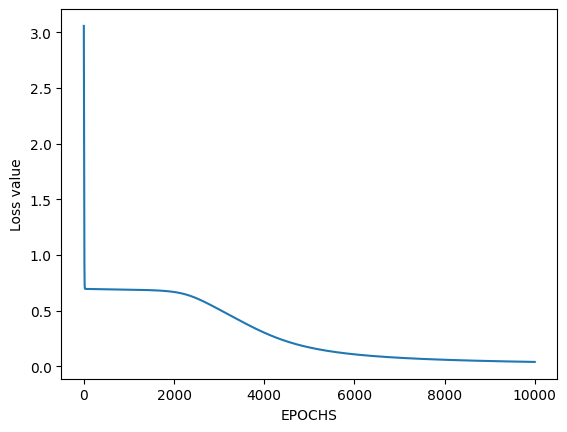

```python
# Train

losses = []
iterations = 10000

for i in range(iterations):
    z1, a1, z2, a2 = forward_prop(w1, w2, total_input)
    loss = -(1/samples)*np.sum(y*np.log(a2)+(1-y)*np.log(1-a2))
    losses.append(loss)
    da2, dw2, dz1, dw1 = back_prop(samples, w1, w2, z1, a1, z2, a2, y)
    w2 = w2-lr*dw2
    w1 = w1-lr*dw1

# We plot losses to see how our network is doing
plt.plot(losses)
plt.xlabel("EPOCHS")
plt.ylabel("Loss value")
```

Reference Article (Bharath K): https://blog.paperspace.com/constructing-neural-networks-from-scratch/

# Question #3

Build a Deep Learning model using Keras to classify the Diabetes dataset

```python
dia = pd.read_csv('diabetes.csv')
```

Use a fixed number of Epochs or Early Stopping, a batch size and optimizer of your choice.

```python
opt = 'Adam'
loss_function = 'binary_crossentropy'
epoch_size = 30
```

Make the following changes to your architecture and describe how it impact model performance? Use comparative loss/accuracy plots as needed to describe the difference in convergence with and without these hyperparameters. Use Tensorboard to analyze the model graph and results from the metrics.

- i - Add more hidden layers.
- ii - Add Batch Normalization in one or more layers.
- iii - AddL1/L2regularizationinoneormorelayers.
- iv - Add Dropout in one or more layers.

```python
# Split the dataset
X = dia.drop('Outcome', axis=1)
y = dia['Outcome']

# Split the dataset into train/test
X_train, X_test, y_train, y_test = train_test_split(X, y, test_size=0.2, random_state=777)

# Split the training set into train/validation
X_train, X_val, y_train, y_val = train_test_split(X_train, y_train, test_size=0.2, random_state=777)
```

# Base Model

```python
# Build the base modelwith 8 neurons
model = keras.Sequential([
    keras.layers.Dense(8, activation='relu', input_dim=X_train.shape[1]),
    keras.layers.Dense(1, activation='sigmoid') # Use sigmoid for binary classification
])

# Compile the model
model.compile(optimizer=opt,
              loss=loss_function,
              metrics=['accuracy'])

# Define the early stopping callback
early_stopping = tf.keras.callbacks.EarlyStopping(
    monitor='val_loss',  # Metric to monitor for improvement
    patience=10,  # Number of epochs with no improvement after which training will be stopped
    restore_best_weights=True  # Restore the weights of the best epoch
)

with tf.device('/device:GPU:0'):
    # Train the model on GPU
    model.fit(X_train,
              y_train,
              epochs=epoch_size,
              batch_size=24,
              validation_data=(X_val, y_val),
              callbacks=[early_stopping])

# save loss history
model_hist = model.history.history['loss']

# Evaluate the model
loss, accuracy = model.evaluate(X_test, y_test)
print('Test loss:', loss)
print('Test accuracy:', accuracy)
```

```
Test loss: 0.8079807162284851
Test accuracy: 0.701298713684082
```

# Part i: Add More Hidden Layers

```python
# Build the model
model_more_hidden = keras.Sequential([
    keras.layers.Dense(64, activation='relu'),
    keras.layers.Dense(64, activation='relu'),
    keras.layers.Dense(64, activation='relu'),
    keras.layers.Dense(64, activation='relu'),
    keras.layers.Dense(64, activation='relu'),
    keras.layers.Dense(64, activation='relu'),
    keras.layers.Dense(1, activation='sigmoid')
])

# Compile the model
model_more_hidden.compile(optimizer=opt,
               loss=loss_function,
               metrics=['accuracy'])

# Create a TensorBoard callback
tensorboard_callback = tf.keras.callbacks.TensorBoard(log_dir='./logs', histogram_freq=1)

# Define the early stopping callback
early_stopping = tf.keras.callbacks.EarlyStopping(
    monitor='val_loss',  # Metric to monitor for improvement
    patience=10,  # Number of epochs with no improvement after which training will be stopped
    restore_best_weights=True  # Restore the weights of the best epoch
)

# Train the model
with tf.device('/device:GPU:0'):
    model_more_hidden.fit(X_train,
                      y_train,
                      epochs=epoch_size,
                      batch_size=16,
                      validation_data=(X_val, y_val),
                      callbacks=[tensorboard_callback, early_stopping])

# save loss history
model_more_hidden_hist = model_more_hidden.history.history['loss']

# Evaluate the model
loss_hidden, accuracy_hidden = model_more_hidden.evaluate(X_test, y_test)
print('Test loss:', loss_hidden)
print('Test accuracy:', accuracy_hidden)
```

```
Test loss: 1.0618184804916382
Test accuracy: 0.5194805264472961
```

# Part ii: Add More Hidden Layers + Batch Normalization

```python
# Build the model
model_more_hidden_batch = keras.Sequential([
    keras.layers.Dense(64, activation='relu'),
    keras.layers.Dense(64, activation='relu'),
    keras.layers.BatchNormalization(), # Batch Normalization
    keras.layers.Dense(64, activation='relu'),
    keras.layers.Dense(64, activation='relu'),
    keras.layers.BatchNormalization(), # Batch Normalization
    keras.layers.Dense(64, activation='relu'),
    keras.layers.Dense(64, activation='relu'),
    keras.layers.Dense(1, activation='sigmoid')
])

# Compile the model
model_more_hidden_batch.compile(optimizer=opt,
               loss=loss_function,
               metrics=['accuracy'])

# Create a TensorBoard callback
tensorboard_callback = tf.keras.callbacks.TensorBoard(log_dir='./logs', histogram_freq=1)

# Define the early stopping callback
early_stopping = tf.keras.callbacks.EarlyStopping(
    monitor='val_loss',  # Metric to monitor for improvement
    patience=10,  # Number of epochs with no improvement after which training will be stopped
    restore_best_weights=True  # Restore the weights of the best epoch
)

# Train the model
with tf.device('/device:GPU:0'):
    model_more_hidden_batch.fit(X_train,
                      y_train,
                      epochs=epoch_size,
                      batch_size=16,
                      validation_data=(X_val, y_val),
                      callbacks=[tensorboard_callback, early_stopping])

# save loss history
model_more_hidden_batch_hist = model_more_hidden_batch.history.history['loss']

# Evaluate the model
loss_hidden, accuracy_hidden = model_more_hidden_batch.evaluate(X_test, y_test)
print('Test loss:', loss_hidden)
print('Test accuracy:', accuracy_hidden)
```

```
Test loss: 0.5614093542098999
Test accuracy: 0.7077922224998474
```

```python
# Build the model
model_reg = keras.Sequential([
    keras.layers.Dense(64, activation='relu'),
    keras.layers.Dense(64, activation='relu', kernel_regularizer=regularizers.l2(0.05)), # Regularization
    keras.layers.BatchNormalization(), # Batch Normalization
    keras.layers.Dense(64, activation='relu'),
    keras.layers.Dense(64, activation='relu', kernel_regularizer=regularizers.l2(0.05)), # Regularization
    keras.layers.BatchNormalization(), # Batch Normalization
    keras.layers.Dense(64, activation='relu'),
    keras.layers.Dense(64, activation='relu'),
    keras.layers.Dense(1, activation='sigmoid')
])

# Compile the model
model_reg.compile(optimizer=opt,
               loss=loss_function,
               metrics=['accuracy'])

# Create a TensorBoard callback
tensorboard_callback = tf.keras.callbacks.TensorBoard(log_dir='./logs', histogram_freq=1)

# Define the early stopping callback
early_stopping = tf.keras.callbacks.EarlyStopping(
    monitor='val_loss',  # Metric to monitor for improvement
    patience=10,  # Number of epochs with no improvement after which training will be stopped
    restore_best_weights=True  # Restore the weights of the best epoch
)

# Train the model
with tf.device('/device:GPU:0'):
    model_reg.fit(X_train,
                      y_train,
                      epochs=epoch_size,
                      batch_size=16,
                      validation_data=(X_val, y_val),
                      callbacks=[tensorboard_callback, early_stopping])

# save loss history
model_model_reg_hist = model_reg.history.history['loss']

# Evaluate the model
loss_hidden, accuracy_hidden = model_reg.evaluate(X_test, y_test)
print('Test loss:', loss_hidden)
print('Test accuracy:', accuracy_hidden)
```

```
Test loss: 0.8444749712944031
Test accuracy: 0.7337662577629089
```

### Note: Adding more L2 Regularization on top of the current model slightly improves the Test accuracy from 71% to 73%. Lastly we will add dropout to help generalize better.

```python
# Build the model
model_reg_drop = keras.Sequential([
    keras.layers.Dense(64, activation='relu'),
    keras.layers.Dense(64, activation='relu', kernel_regularizer=regularizers.l2(0.05)), # Regularization
    keras.layers.BatchNormalization(), # Batch Normalization
    keras.layers.Dense(64, activation='relu'),
    keras.layers.Dense(64, activation='relu', kernel_regularizer=regularizers.l2(0.05)), # Regularization
    keras.layers.BatchNormalization(), # Batch Normalization
    keras.layers.Dense(64, activation='relu'),
    keras.layers.Dropout(0.25), # Dropout
    keras.layers.Dense(64, activation='relu'),
    keras.layers.Dense(1, activation='sigmoid')
])

# Compile the model
model_reg_drop.compile(optimizer=opt,
               loss=loss_function,
               metrics=['accuracy'])

# Create a TensorBoard callback
tensorboard_callback = tf.keras.callbacks.TensorBoard(log_dir='./logs', histogram_freq=1)

# Define the early stopping callback
early_stopping = tf.keras.callbacks.EarlyStopping(
    monitor='val_loss',  # Metric to monitor for improvement
    patience=10,  # Number of epochs with no improvement after which training will be stopped
    restore_best_weights=True  # Restore the weights of the best epoch
)

# Train the model
with tf.device('/device:GPU:0'):
    model_reg_drop.fit(X_train,
                       y_train,
                       epochs=epoch_size,
                       batch_size=16,
                       validation_data=(X_val, y_val),
                       callbacks=[tensorboard_callback, early_stopping])

# save loss history
model_model_reg_drop_hist = model_reg_drop.history.history['loss']

# Evaluate the model
loss_hidden, accuracy_hidden = model_reg_drop.evaluate(X_test, y_test)
print('Test loss:', loss_hidden)
print('Test accuracy:', accuracy_hidden)
```

```
Test loss: 0.6314762830734253
Test accuracy: 0.7077922224998474
```

```python
model_reg_drop.summary()
```

```
Model: "sequential_24"
_________________________________________________________________
 Layer (type)                Output Shape              Param #
=================================================================
 dense_133 (Dense)           (None, 64)                576

 dense_134 (Dense)           (None, 64)                4160

 batch_normalization_24 (Bat  (None, 64)               256
 chNormalization)

 dense_135 (Dense)           (None, 64)                4160

 dense_136 (Dense)           (None, 64)                4160

 batch_normalization_25 (Bat  (None, 64)               256
 chNormalization)

 dense_137 (Dense)           (None, 64)                4160

 dropout_9 (Dropout)         (None, 64)                0

 dense_138 (Dense)           (None, 64)                4160

 dense_139 (Dense)           (None, 1)                 65

=================================================================
Total params: 21,953
Trainable params: 21,697
Non-trainable params: 256
_________________________________________________________________
```

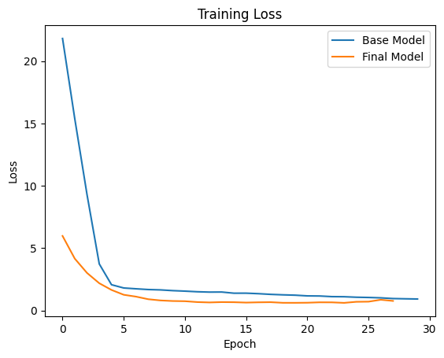

```python
# Plot the training loss
plt.plot(model_hist, label='Base Model')
plt.plot(model_model_reg_drop_hist, label='Final Model')
plt.title('Training Loss')
plt.xlabel('Epoch')
plt.ylabel('Loss')
plt.legend()
plt.show()
```

# Part C

Explain how adding various hyperparameters may have impacted model performance.

**Overall the base model Test Accuracy was 70% and the final model with extra hidden layers, batch norm, regularization, and dropout had a Test Accuracy of 71%.**

**Loss Plot Summary:**

- This loss plot comparison between the final model and base model shows the additional hyperparameters improved loss overall. At the beginning the final model has a much lower loss but the base model quickly catches up around 5 epochs. Both level off after 5-10 epochs suggesting we can stop the training at this point.

# Part D

Summarize the model architecture and provide a manual calculation for the total number of parameters used in your neural network and check your results with Keras summary.

**Summary:** The final model had a total of 10 layers, including the final sigmoid layer that performs the classification to 0 or 1. Aside from the last sigmoid layer, all other layers used ReLu activations. There are also 2 BatchNormalization layers, a 25% dropout layer, and 2 layers that include L2 regularization.

**Parameters:** 21,953 Total

m = input n = output

- Layer 1: (m+1)*n = (8+1)*64 = 576
- Layer 2: (m+1)*n = (64+1)*64 = 4,160
- Layer 3: BatchNorm = (m+m)*n = (64+64)*2 = 256
- Layer 4: (m+1)*n = (64+1)*64 = 4,160
- Layer 5: (m+1)*n = (64+1)*64 = 4,160
- Layer 6: BatchNorm = (m+m)*n = (64+64)*2 = 256
- Layer 7: (m+1)*n = (64+1)*64 = 4,160
- Layer 8: Dropout = 0
- Layer 9: (m+1)*n = (64+1)*64 = 4,160
- Layer 10: (m+n) = (64+1) = 65

Sum = 576 + 4160 + 256 + 4160 + 4160 + 256 + 4160 + 0 + 4160 + 65 = 21,953

# Part E

Compare model performance metrics (Accuracy, F1 Score, Confusion Matrix, etc.), with at least two classical machine learning models built using sklearn.

2 Classical Models:

- Logistic Regression
- SVM

#### Classical Model - Logistic Regression

```python
from sklearn.linear_model import LogisticRegression
from sklearn.metrics import accuracy_score
import warnings
warnings.filterwarnings("ignore")

# Create a logistic regression model
logreg = LogisticRegression()

# Fit the model on the training data
with tf.device('/device:GPU:0'):
    logreg.fit(X_train, y_train)

# Make predictions on the test data
y_pred = logreg.predict(X_test)

# Evaluate the model
accuracy = accuracy_score(y_test, y_pred)
precision = precision_score(y_test, y_pred)
recall = recall_score(y_test, y_pred)
f1 = f1_score(y_test, y_pred)

# Print the evaluation metrics
print("Logistic Regression Accuracy:", accuracy)
print("Logistic Regression Precision:", precision)
print("Logistic Regression Recall:", recall)
print("Logistic Regression F1-score:", f1)
```

```
Logistic Regression Accuracy: 0.7597402597402597
Logistic Regression Precision: 0.6666666666666666
Logistic Regression Recall: 0.5490196078431373
Logistic Regression F1-score: 0.6021505376344086
```

#### Classical Model - SVM

```python
from sklearn.svm import SVC
from sklearn.metrics import accuracy_score

# Create an SVM model
svm = SVC()

# Fit the model on the training data
with tf.device('/device:GPU:0'):
    svm.fit(X_train, y_train)

# Make predictions on the test data
y_pred = svm.predict(X_test)

# Evaluate the model
accuracy = accuracy_score(y_test, y_pred)
precision = precision_score(y_test, y_pred)
recall = recall_score(y_test, y_pred)
f1 = f1_score(y_test, y_pred)

# Print the evaluation metrics
print("SVM Accuracy:", accuracy)
print("SVM Precision:", precision)
print("SVM Recall:", recall)
print("SVM F1-score:", f1)
```

```
SVM Accuracy: 0.7727272727272727
SVM Precision: 0.75
SVM Recall: 0.47058823529411764
SVM F1-score: 0.5783132530120481
```

### Part E - Summary

Comparing our deep learning model against 2 classical ML models showed the following Test accuracy results:

- Deep Learning: 70.78%
- Logistic Regression: 76%
- SVM: 77%

This means that simpler models can perform just as well as a more complicated neural net model with the diabetes dataset. Even though the deep learning model achieves a strong accuracy, the much simpler logistic regression and SVM models outperforms it. For this reason, I would suggest starting with classical machine learning models first before implementing a deep learning solution as they are quicker and more efficient to implement.

# Question #4

Neural networks are Universal Function Approximators. Build two models using Keras – one to learn the Sine function and the second to learn other arbitrary but non-trivial function of your choice. (15)

- Plot the learned mapping for a given range (-𝜋, 𝜋) and compare it with the Sine wave for the first model and a suitable range for the second model.
- Summarize the model architectures for both models.

## Sine Function

```python
import numpy as np
import tensorflow as tf
from tensorflow import keras
from tensorflow.keras import layers

X = np.random.uniform(-20, 20, size=100000)
y = np.sin(X)
```

```python
# Build the Keras model
model = keras.Sequential([
    layers.Dense(16, activation='tanh', input_shape=(1,)),
    layers.Dense(16, activation='tanh'),
    layers.Dense(1)
])

# Compile the model
model.compile(optimizer='adam',
              loss='mean_squared_error')

with tf.device('/device:GPU:0'):
    model.fit(X, y, epochs=20, batch_size=32)
```

```python
model.summary()
```

```
Model: "sequential_35"
_________________________________________________________________
 Layer (type)                Output Shape              Param #
=================================================================
 dense_170 (Dense)           (None, 16)                32

 dense_171 (Dense)           (None, 16)                272

 dense_172 (Dense)           (None, 1)                 17

=================================================================
Total params: 321
Trainable params: 321
Non-trainable params: 0
_________________________________________________________________
```

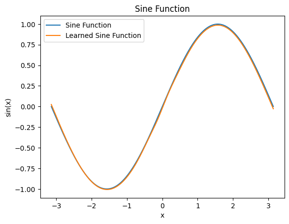

```python
X = np.linspace(-np.pi, np.pi, 10000)
y = np.sin(X)

predictions = model.predict(X)

# Create the plot
plt.plot(X, y, label='Sine Function') # true sin function
plt.plot(X, predictions, label='Learned Sine Function') # modeled sin function

# Set the plot title and labels
plt.title('Sine Function')
plt.xlabel('x')
plt.ylabel('sin(x)')

# Display the plot
plt.legend()
plt.show()
```

### Architecture Summary

The model used to learn the Sine function has 3 total layers. The first 2 layers have 16 neurons (units) and tanh activation functions. The input accepts a 1 dimensional input. The last layer is a fully connected layer with a single neuron. The model has a total of 321 parameters.

## Sigmoid Function

```python
X = np.random.uniform(-10, 10, size=5000)
y = 1 / (1 + np.exp(-X))
```

```python
# Build the Keras model
model = keras.Sequential([
    layers.Dense(16, activation='sigmoid', input_shape=(1,)),
    layers.Dense(16, activation='sigmoid'),
    layers.Dense(1)
])

# Compile the model
model.compile(optimizer='adam',
              loss='mean_squared_error')

with tf.device('/device:GPU:0'):
    model.fit(X, y, epochs=20, batch_size=32)
```

```python
model.summary()
```

```
Model: "sequential_34"
_________________________________________________________________
 Layer (type)                Output Shape              Param #
=================================================================
 dense_167 (Dense)           (None, 16)                32

 dense_168 (Dense)           (None, 16)                272

 dense_169 (Dense)           (None, 1)                 17

=================================================================
Total params: 321
Trainable params: 321
Non-trainable params: 0
_________________________________________________________________
```

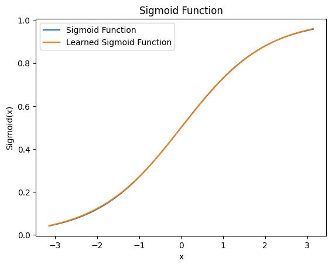

```python
X = np.linspace(-np.pi, np.pi, 10000)
y = 1 / (1 + np.exp(-X))

predictions = model.predict(X)

# Create the plot
plt.plot(X, y, label='Sigmoid Function') # true sigmoid function
plt.plot(X, predictions, label='Learned Sigmoid Function') # modeled sigmoid function

# Set the plot title and labels
plt.title('Sigmoid Function')
plt.xlabel('x')
plt.ylabel('Sigmoid(x)')

# Display the plot
plt.legend()
plt.show()
```

### Architecture Summary

The model used to learn the sigmoid function has 3 total layers. The first 2 layers have 16 neurons (units) and sigmoid activation functions. The input accepts a 1 dimensional input. The last layer is a fully connected layer with a single neuron. The model has a total of 321 parameters.